# hw5

Jessie Bustin Github: jebustin

4/6/2020

### 1.

Verifying correct dl and import:

```r
head(liqSales)
```

```
## # A tibble: 6 x 24
##   `Invoice/Item N~ Date  `Store Number` `Store Name` Address City  `Zip Code`
##   <chr>            <chr>          <dbl> <chr>        <chr>   <chr>      <dbl>
## 1 INV-16712000040  01/0~           2500 Hy-Vee Food~ 3800 W~ Ames       50010
## 2 INV-16712000012  01/0~           2500 Hy-Vee Food~ 3800 W~ Ames       50010
## 3 INV-16712000070  01/0~           2500 Hy-Vee Food~ 3800 W~ Ames       50010
## 4 INV-16712000009  01/0~           2500 Hy-Vee Food~ 3800 W~ Ames       50010
## 5 INV-16712000160  01/0~           2500 Hy-Vee Food~ 3800 W~ Ames       50010
## 6 INV-16712000119  01/0~           2500 Hy-Vee Food~ 3800 W~ Ames       50010
## # ... with 17 more variables: `Store Location` <chr>, `County Number` <dbl>,
## #   County <chr>, Category <dbl>, `Category Name` <chr>, `Vendor Number` <chr>,
## #   `Vendor Name` <chr>, `Item Number` <dbl>, `Item Description` <chr>,
## #   Pack <dbl>, `Bottle Volume (ml)` <dbl>, `State Bottle Cost` <dbl>, `State
## #   Bottle Retail` <dbl>, `Bottles Sold` <dbl>, `Sale (Dollars)` <dbl>, `Volume
## #   Sold (Liters)` <dbl>, `Volume Sold (Gallons)` <dbl>
```

### 2.

1. Using substr() to extract lat and long and converting to numeric:

```r
liqSales <- liqSales %>%
    mutate(Latitude = substr(liqSales$'Store Location', 8, 17) %>%
           as.numeric(),
           Longitude = substr(liqSales$'Store Location', 19, 27) %>%
           as.numeric())
```

At this point I did notice that printing the lat and long columns makes it appear as though they were rounded. Upon further research I found that this was a printing issue and not an issue with the actual data. You can adjust the number of digits printed so that it doesn’t round by passing digit = as a paramenter in the method used to print.

2. I changed the date column into a dater. I also changed some of the categorical variables to factors. I decided against changed the vendor number to numeric as this is more of an ID so it qualitative not quantitative. I also found some spelling errors in the Category Names so I merged those.

```r
liqSales$'Store Name' <- as.factor(liqSales$'Store Name')
liqSales$Address <- as.factor(liqSales$Address)
liqSales$'Vendor Number' <- as.factor('Vendor Number')
liqSales$'Vendor Name' <- as.factor(liqSales$'Vendor Name')
liqSales <- liqSales %>%
  mutate(Date= as.Date(Date, format = "%m/%d/%Y"))

liqSales$'Category Name' = ifelse(liqSales$'Category Name' %in% c('Imported Vodkas','Imported Vodka'), 'Imported Vodkas', liqSales$'Category Name')

liqSales$'Category Name' = ifelse(liqSales$'Category Name' %in% c('Temporary & Specialty Packages','Temporary &  Specialty Packages'), 'Temporary & Specialty Packages', liqSales$'Category Name')

liqSales$'Category Name' = ifelse(liqSales$'Category Name' %in% c('Imported Distilled Spirits Specialty','Imported Distilled Spirit Specialty'), 'Imported Distilled Spirits Specialty', liqSales$'Category Name')

liqSales$'Category Name' = ifelse(liqSales$'Category Name' %in% c('Imported Cordials & Liqueurs','Imported Cordials & Liqueur'), 'Imported Cordials & Liqueurs', liqSales$'Category Name')

liqSales$'Category Name' = ifelse(liqSales$'Category Name' %in% c('Cocktails / RTD','Cocktails /RTD'), 'Cocktails / RTD', liqSales$'Category Name')

liqSales$'Category Name' = ifelse(liqSales$'Category Name' %in% c('American Vodkas','American Vodka'), 'American Vodkas', liqSales$'Category Name')

liqSales$'Category Name' = ifelse(liqSales$'Category Name' %in% c('American Distilled Spirits Specialty','American Distilled Spirit Specialty'), 'American Distilled Spirits Specialty', liqSales$'Category Name')

liqSales$'Category Name' <- as.factor(liqSales$'Category Name')

str(liqSales)
```

```
## Classes 'spec_tbl_df', 'tbl_df', 'tbl' and 'data.frame': 63103 obs. of  26 variables:
##  $ Invoice/Item Number  : chr  "INV-16712000040" "INV-16712000012" "INV-16712000070" "INV-16712000009" ...
##  $ Date                 : Date, format: "2019-01-03" "2019-01-03" ...
##  $ Store Number         : num  2500 2500 2500 2500 2500 ...
##  $ Store Name           : Factor w/ 32 levels "AJ's Liquor / Ames",..: 15 15 15 15 15 15 15 15 1 15 ...
##  $ Address              : Factor w/ 32 levels "110 Airport Road",..: 22 22 22 22 22 22 22 22 25 22 ...
##  $ City                 : chr  "Ames" "Ames" "Ames" "Ames" ...
##  $ Zip Code             : num  50010 50010 50010 50010 50010 ...
##  $ Store Location       : chr  NA NA NA NA ...
##  $ County Number        : num  85 85 85 85 85 85 85 85 85 85 ...
##  $ County               : chr  "STORY" "STORY" "STORY" "STORY" ...
##  $ Category             : num  1042100 1012100 1031100 1012100 1081400 ...
##  $ Category Name        : Factor w/ 44 levels "100% Agave Tequila",..: 24 13 10 13 8 3 17 44 13 41 ...
##  $ Vendor Number        : Factor w/ 1 level "Vendor Number": 1 1 1 1 1 1 1 1 1 1 ...
##  $ Vendor Name          : Factor w/ 129 levels "3-Oaks Distillery, LLC",..: 27 27 104 27 59 33 43 70 27 12 ...
##  $ Item Number          : num  28867 11294 37936 10805 82867 ...
##  $ Item Description     : chr  "Tanqueray Gin" "Crown Royal" "Skol Vodka" "Crown Royal Regal Apple" ...
##  $ Pack                 : num  12 24 12 24 12 12 6 6 12 12 ...
##  $ Bottle Volume (ml)   : num  1000 375 750 375 1000 750 1750 1750 750 375 ...
##  $ State Bottle Cost    : num  15.5 8 3.64 8 7.87 ...
##  $ State Bottle Retail  : num  23.25 12 5.46 12 11.81 ...
##  $ Bottles Sold         : num  12 4 12 4 12 3 6 12 2 4 ...
##  $ Sale (Dollars)       : num  279 48 65.5 48 141.7 ...
##  $ Volume Sold (Liters) : num  12 1.5 9 1.5 12 2.25 10.5 21 1.5 1.5 ...
##  $ Volume Sold (Gallons): num  3.17 0.39 2.37 0.39 3.17 0.59 2.77 5.54 0.39 0.39 ...
##  $ Latitude             : num  NA NA NA NA NA NA NA NA NA NA ...
##  $ Longitude            : num  NA NA NA NA NA NA NA NA NA NA ...
```

3. I used the date methods to extract day, month, and year.

```r
liqSales <- liqSales %>%
    mutate(Month = month(Date),
           Day = day(Date),
           Year = year(Date))
```

### 3.

```
## Warning: Removed 20842 rows containing missing values (geom_point).
```

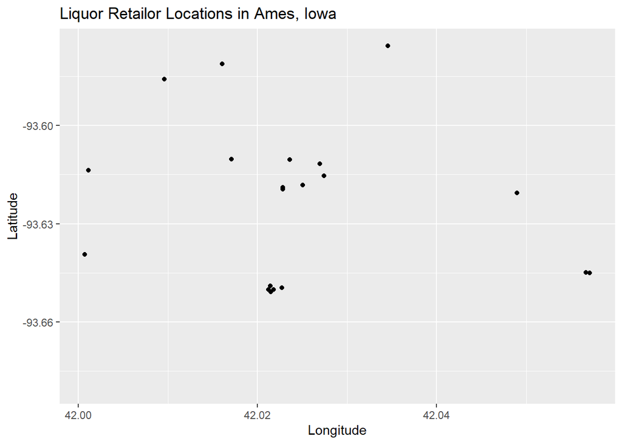

```r
liqSales %>%
  ggplot(aes(x = Longitude, y = Latitude)) +
  geom_point() +
  ggtitle("Liquor Retailor Locations in Ames, Iowa")
```

[figure not shown]

```r
liqSales %>%
  group_by('Category Name') %>%
  ggplot(aes(x = liqSales$'Category Name', y = 'Volume Sold
             (Liters)')) +
  geom_bar(stat="identity") +
  coord_flip() +
  ggtitle("Volume of Liquor Sold by Type") +
  xlab("Type of Liquor") +
  ylab("Volume (Liters)")
```

### 4.

```r
liqSales %>%
  filter(Year == 2019) %>%
  group_by(Date) %>%
  summarize(Count = n(), Volume = sum(`Volume Sold (Liters)`), Cost =
            sum(`Sale (Dollars)`))
```

```
## # A tibble: 157 x 4
##    Date       Count Volume    Cost
##    <date>     <int>  <dbl>   <dbl>
##  1 2019-01-03   957  6816. 112009.
##  2 2019-01-04   143  1256.  16766.
##  3 2019-01-09   944  6732.  99703.
##  4 2019-01-10     2   135    1457.
##  5 2019-01-11   177  1205.  16481.
##  6 2019-01-16   912  8227. 118597.
##  7 2019-01-18    62   232.   4483.
##  8 2019-01-24  1221  9239. 139658.
##  9 2019-01-25   253  2329.  31893.
## 10 2019-01-30  1082  8752. 127225.
## # ... with 147 more rows
```

### 5.

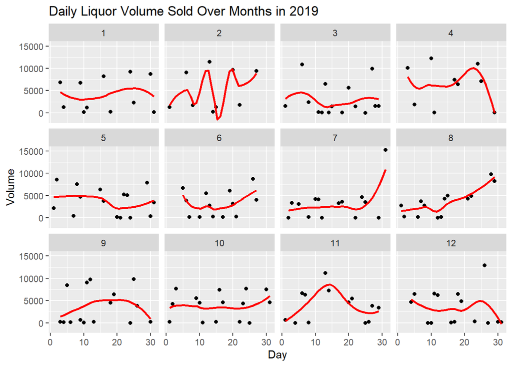

```r
liqSales %>%
  filter(Year == 2019) %>%
  group_by(Date) %>%
  summarize(Count = n(), Volume = sum(`Volume Sold (Liters)`), Cost =
            sum(`Sale (Dollars)`)) %>%
  mutate(Month = month(Date), Day = day(Date)) %>%
  ggplot(aes(x = Day, y = Volume)) +
  geom_point() +
  geom_smooth(method = 'loess', n = 30, se = FALSE, color = "red") +
  facet_wrap(~Month) +
  ggtitle("Daily Liquor Volume Sold Over Months in 2019")
```

There are a lot of very predictable trends that appear when we look at the total volumn of alcohol sold in 2019 by day. First of all, there is a weekly cycle. Since this dataset is looking at wholesales and not the purchases of consumers this makes sense. While consumers also cycle weekly by drinking more on the weekends, retailers have order schedules that amplify this cycle. Stores will place liquor orders on preset days of the week and Iowa Bev then makes deliveries in batches. Some weeks this happens mostly on one day but sometimes it takes 2 days and you see 2 days in a row with a high volumn of liquor sold. I have extensive (10+ years) personal experience installing point of sale and inventory systems for both on premise and off alcohol sales and my personal knowledge maps to what we see in this graph. Also, the highest days of the year are right before New Years Eve as those placing orders are given larger budgets in preparation for the holiday as well as at the end of July as Ames gets ready for a huge influx of students.

### 6.

ISU had home football games in 2019 on 8/31, 9/14, 9/21, 10/5, 10/26, 11/16, and 11/23. The following graph has home games shown with a red and gold vertical line. Prior to each game there is a spike in sales. These spikes follow the weekly cyclical nature discussed in the previous problem. There are 3 time periods on this graph where the spike in sales prior to a game took place over 2 days. This happens right before the Iowa game and right before the last 2 home games. For analysis, it is important to think about the totals for these 2 days. Prior to the Iowa game over 18,000 liters of alcohol were ordered! That is over 1/2 a liter for every ISU student!

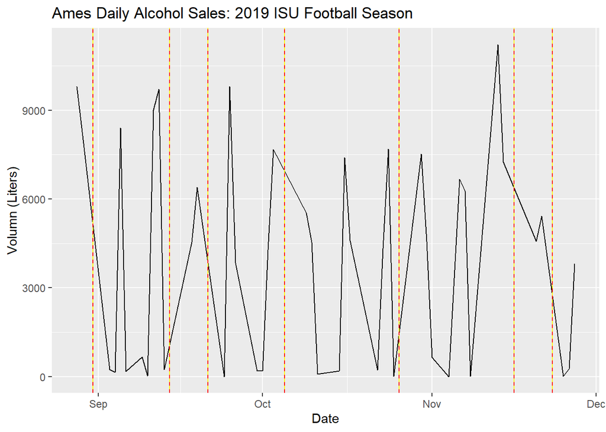

```r
liqSales %>%
  group_by(Date) %>%
  filter(Date >= as.Date("2019-08-25") && Date <=
           as.Date("2019-11-28")) %>%
  summarize(Count = n(), Volume = sum(`Volume Sold (Liters)`), Cost =
            sum(`Sale (Dollars)`)) %>%
  ggplot(aes(x = Date, y = Volume)) +
  geom_line() +
  scale_x_date() +
  geom_vline(xintercept = as.Date("2019-08-31"), color = "yellow") +
  geom_vline(xintercept = as.Date("2019-09-14"), color = "yellow") +
  geom_vline(xintercept = as.Date("2019-09-21"), color = "yellow") +
  geom_vline(xintercept = as.Date("2019-10-05"), color = "yellow") +
  geom_vline(xintercept = as.Date("2019-10-26"), color = "yellow") +
  geom_vline(xintercept = as.Date("2019-11-16"), color = "yellow") +
  geom_vline(xintercept = as.Date("2019-11-23"), color = "yellow") +
  geom_vline(xintercept = as.Date("2019-08-31"), linetype="dashed",
             color = "red") +
  geom_vline(xintercept = as.Date("2019-09-14"), linetype="dashed",
             color = "red") +
  geom_vline(xintercept = as.Date("2019-09-21"), linetype="dashed",
             color = "red") +
  geom_vline(xintercept = as.Date("2019-10-05"), linetype="dashed",
             color = "red") +
  geom_vline(xintercept = as.Date("2019-10-26"), linetype="dashed",
             color = "red") +
  geom_vline(xintercept = as.Date("2019-11-16"), linetype="dashed",
             color = "red") +
  geom_vline(xintercept = as.Date("2019-11-23"), linetype="dashed",
             color = "red") +
  ggtitle("Ames Daily Alcohol Sales: 2019 ISU Football Season") +
  ylab("Volumn (Liters)")
```